# Module 1. Foundations of longitudinal data

Slides

## Longitudinal data follow the same people over time

- Show **change**, **differences in change** and **individual trajectories**
- Measurements on one person resemble each other: not independent
- Timing and number of measurements vary between people

**Simulated data**

All examples use simulated data from fictional studies. Results illustrate methods; they are not empirical findings.

## Learning outcomes

1. **1.1** Classify a design as longitudinal, repeated-measures, clustered or cross-sectional.
2. **1.2** Identify subject, observation, visit and measurement occasion.
3. **1.3** Distinguish and estimate within- and between-subject variation in WALK.
4. **1.4** Describe balanced/unbalanced designs, irregular visits and unequal follow-up.
5. **1.5** State research questions about change with their estimands.
6. **1.6** Show by simulation how ignoring correlation changes SEs, and in which direction.

# Kinds of design

## Four data structures

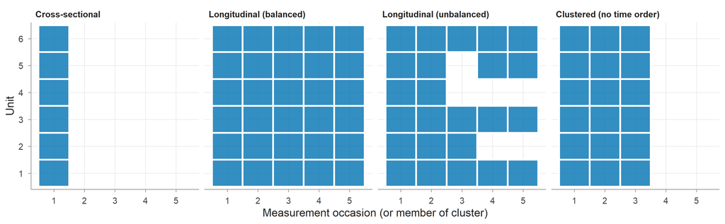

## A longitudinal study is clustered data with a time order

- **Cross-sectional:** each unit once (WALK baseline file)
- **Repeated measures:** more than one measurement per unit (time not necessarily of interest)
- **Longitudinal:** repeated over time, and change is the question (WALK, KIDNEY)
- **Clustered:** units within groups (WALK participants within 8 clinics)
- The independent unit in WALK is the **participant**, not the measurement

## Try it

Workbook **Exercise 1**: classify six study designs and justify each classification.

# Anatomy of a longitudinal dataset

## Subject, observation, visit, measurement occasion

```r
walk |> filter(id %in% c("W001", "W002")) |>
  select(id, arm, visit, month_sched, month, sbp)
```

```
#> # A tibble: 8 × 6
#>   id    arm   visit month_sched month   sbp
#>   <chr> <fct> <dbl>       <dbl> <dbl> <dbl>
#> 1 W001  EP        1           0  0      150
#> 2 W001  EP        2           1  1.09   148
#> 3 W001  EP        3           3  2.95   133
#> 4 W001  EP        4           6  6.04   140
#> 5 W001  EP        5           9  9.68   132
#> 6 W001  EP        6          12 11.13   132
#> 7 W002  SP        1           0  0      176
#> 8 W002  SP        2           1  1.01   165
```

## Actual times scatter around the schedule, more so later

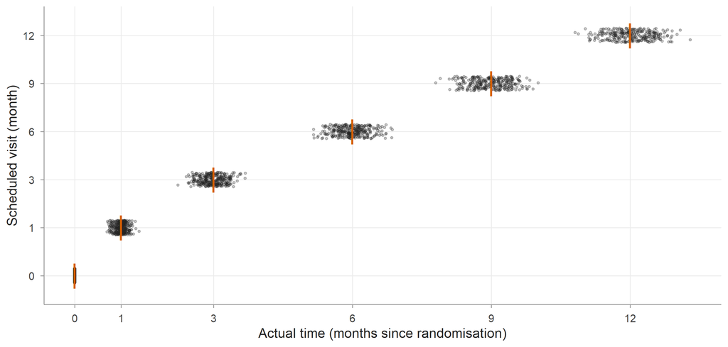

## WALK is balanced by design, unbalanced in practice

```r
walk |> count(id, name = "n_obs") |> count(n_obs, name = "participants")
```

```
#> # A tibble: 6 × 2
#>   n_obs participants
#>   <int>        <int>
#> 1     1           15
#> 2     2           13
#> 3     3           14
#> 4     4           14
#> 5     5           66
#> 6     6          238
```

- Missed visits (intermittent), dropout (depends on SBP), irregular timing
- Complete-case analysis would discard about a third of participants

## KIDNEY: irregular visits and unequal follow-up

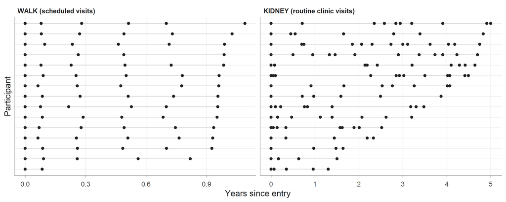

## In KIDNEY, visit timing depends on the outcome

```r
kidney |> arrange(id, years) |> group_by(id) |>
  mutate(gap_months = 12 * (years - lag(years)), prev_egfr = lag(egfr)) |>
  ungroup() |> filter(!is.na(gap_months)) |>
  group_by(previous_egfr_below_30 = prev_egfr < 30) |>
  summarise(n_gaps = n(), mean_gap_months = mean(gap_months))
```

```
#> # A tibble: 2 × 3
#>   previous_egfr_below_30 n_gaps mean_gap_months
#>   <lgl>                   <int>           <dbl>
#> 1 FALSE                    2190           5.425
#> 2 TRUE                      446           2.826
```

## Try it

Workbook **Exercise 2**: identify the subject, observation, visit and measurement occasion in WALK, CLEAR, DIARY and KIDNEY, and summarise balance and follow-up.

# Between and within

## Most of the variation in SBP is between people

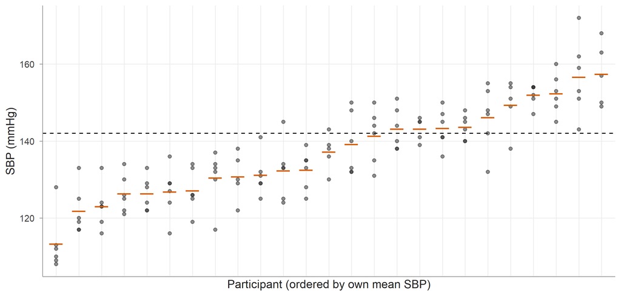

## Measurements are strongly correlated, more so when close in time

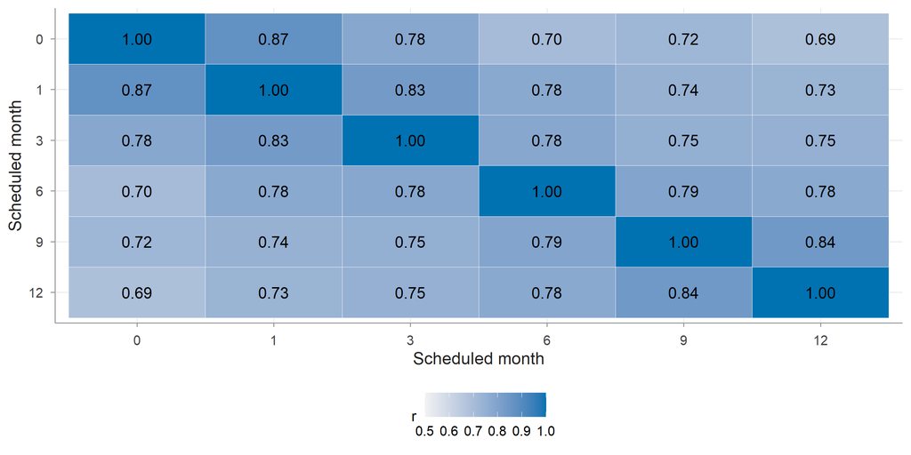

## A random intercept splits the variance in two

$$y_{ij} = \mathbf{x}_{ij}^\top\boldsymbol\beta + b_{0i} + \varepsilon_{ij},\quad b_{0i}\sim N(0,\tau_0^2),\ \varepsilon_{ij}\sim N(0,\sigma^2)$$

- $b_{0i}$: participant $i$’s own level, shared by all their measurements
- $\tau_0^2$ between-subject, $\sigma^2$ within-subject variance
- ICC $\rho_I = \tau_0^2/(\tau_0^2+\sigma^2)$ = correlation of two measurements on one person

## WALK: between-person SD about twice the within-person SD

```r
m_ri <- lmer(sbp ~ visit_f * arm + (1 | id), data = walk, control = lmer_ctrl)
VarCorr(m_ri)
```

```
#>  Groups   Name        Std.Dev.
#>  id       (Intercept) 12.02
#>  Residual              6.15
```

```r
icc_lmer(m_ri)
```

```
#> [1] 0.7925
```

## The constant ICC is an approximation

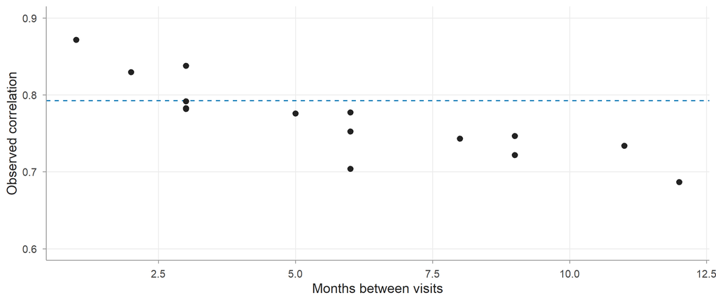

## Try it

Workbook **Exercise 3**: compute the correlation matrix within each arm, fit the random-intercept model and report the variance components.

# Research questions and estimands

## Three kinds of question, three estimands

| Question | WALK / KIDNEY example | Estimand |
| --- | --- | --- |
| Change | Mean change in EP | $\mu_{\text{EP}}(12) - \mu_{\text{EP}}(0)$ |
| Group difference in change | EP vs UC | $[\mu_{\text{EP}}(12) - \mu_{\text{EP}}(0)] - [\mu_{\text{UC}}(12) - \mu_{\text{UC}}(0)]$ |
| Individual trajectories | Variation in eGFR decline | $\tau_1^2$; a person’s slope $\beta_1 + b_{1i}$ |

## Observed means are a first look, not the estimand

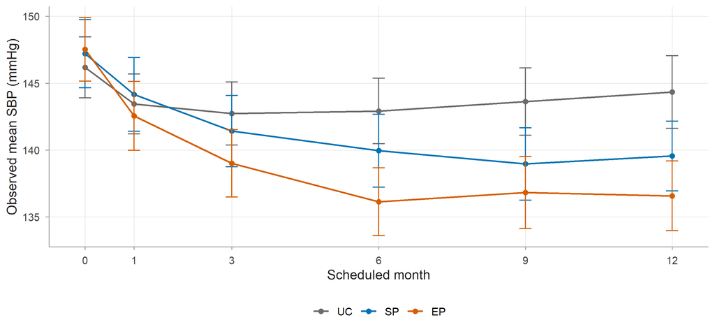

## Preview: the primary model targets the estimand directly

```r
m_primary <- lmer(sbp ~ visit_f * arm + (1 + month | id), data = walk,
                  control = lmer_ctrl)
fixef_table(m_primary) |>
  filter(term %in% c("visit_f12:armSP", "visit_f12:armEP")) |>
  select(term, estimate, lower, upper)
```

```
#>              term estimate  lower  upper
#> 1 visit_f12:armSP   -5.377  -8.17 -2.584
#> 2 visit_f12:armEP   -8.969 -11.79 -6.146
```

## Try it

Workbook **Exercise 4**: write the estimand for four research questions, including one about individual trajectories in KIDNEY.

# Ignoring the dependence

## Two kinds of comparison, two directions of error

- **Between-subject** (arm, sex): information comes from people
  - OLS counts each row as new evidence: **SE too small**
  - Design effect $\approx 1 + (m-1)\rho_I$
- **Within-subject** (change over time): each person is their own control
  - OLS treats between-person variance as noise: **SE too large**
  - Variance inflated by $\approx 1/(1-\rho_I)$

## The simulation: 1,000 trials, two analyses each

```r
d <- sim_two_arm(n_per_arm = 50, times = c(0, 3, 6, 9, 12), b0 = 150,
                 b_time = -0.5, delta = 0, sd_int = 11, sd_slope = 0,
                 cor_int_slope = 0, sd_resid = 6)
lm(y ~ time + trt, data = d)                          # naive OLS
lmer(y ~ time + trt + (1 | id), data = d,
     control = lmer_ctrl)                             # mixed model
```

- Truth: no arm difference; slope −0.5; ICC = 0.77
- Benchmark: the SD of the estimates across replicates

## OLS SEs: too small between, too large within

| Estimand | True SD | OLS SE | Mixed SE | OLS coverage % | Mixed coverage % |
| --- | --- | --- | --- | --- | --- |
| A: arm difference (between-subject) | 2.298 | 1.110 | 2.251 | 65.2 | 94.2 |
| A: time slope (within-subject) | 0.063 | 0.131 | 0.063 | 100.0 | 95.0 |
| B: arm-by-time interaction | 0.145 | 0.260 | 0.149 | 100.0 | 95.0 |

Monte Carlo SE of the true SD: 0.051, 0.001, 0.005; of coverage at most 1.5 points

## The picture behind the table

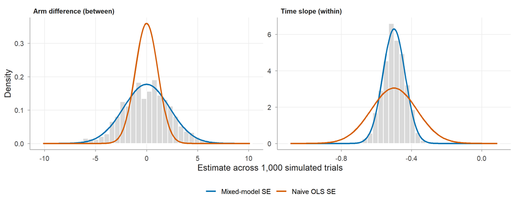

## The same pattern in WALK

| term | se_ols | se_lmm | ratio |
| --- | --- | --- | --- |
| (Intercept) | 0.803 | 1.191 | 0.674 |
| month | 0.124 | 0.076 | 1.638 |
| armSP | 1.133 | 1.683 | 0.673 |
| armEP | 1.133 | 1.683 | 0.673 |
| month:armSP | 0.174 | 0.106 | 1.637 |
| month:armEP | 0.175 | 0.107 | 1.635 |

## Try it

Workbook **Exercise 5**: run a smaller version of the simulation and compute Monte Carlo errors.

## Summary

- Longitudinal = clustered data with a time order; the independent unit is the subject
- Keep subject, observation, visit and measurement occasion distinct; scheduled vs actual time
- WALK: most variation is between people (ICC about 0.79); correlation decays slowly with the gap
- Estimands for change, difference in change, individual trajectories
- Ignoring correlation: between-subject SEs too small, within-subject SEs (usually) too large

## Further reading

- Fitzmaurice et al. (2011), chapters 1–2
- Diggle et al. (2002), chapter 1
- Singer and Willett (2003), chapters 1–2
- Morris et al. (2019): simulation studies and Monte Carlo error

## References

Diggle, Peter J., Patrick J. Heagerty, Kung-Yee Liang, and Scott L. Zeger. 2002. *Analysis of Longitudinal Data*. 2nd edn. Vol. 25. Oxford Statistical Science Series. Oxford University Press. https://doi.org/10.1093/oso/9780198524847.001.0001.

Fitzmaurice, Garrett M., Nan M. Laird, and James H. Ware. 2011. *Applied Longitudinal Analysis*. 2nd edn. Wiley Series in Probability and Statistics. John Wiley & Sons. https://doi.org/10.1002/9781119513469.

Morris, Tim P., Ian R. White, and Michael J. Crowther. 2019. ‘Using Simulation Studies to Evaluate Statistical Methods’. *Statistics in Medicine* 38 (11): 2074–102. https://doi.org/10.1002/sim.8086.

Singer, Judith D., and John B. Willett. 2003. *Applied Longitudinal Data Analysis: Modeling Change and Event Occurrence*. Oxford University Press. https://doi.org/10.1093/acprof:oso/9780195152968.001.0001.